# MIHAI_Carmen-Alexandra_BDSA

2023-03-03

Vizualizarea datelor si a dimensiunii seturilor de date ce urmeaza a fi utilizate in analiza.

```r
glimpse(date2022)
```

```
## Rows: 73,268
## Columns: 79
## $ ResponseId                     <dbl> 1, 2, 3, 4, 5, 6, 7, 8, 9, 10, 11, 12, …
## $ MainBranch                     <chr> "None of these", "I am a developer by p…
## $ Employment                     <chr> NA, "Employed, full-time", "Employed, f…
## $ RemoteWork                     <chr> NA, "Fully remote", "Hybrid (some remot…
## $ CodingActivities               <chr> NA, "Hobby;Contribute to open-source pr…
## $ EdLevel                        <chr> NA, NA, "Master’s degree (M.A., M.S., M…
## $ LearnCode                      <chr> NA, NA, "Books / Physical media;Friend …
## $ LearnCodeOnline                <chr> NA, NA, "Technical documentation;Blogs;…
## $ LearnCodeCoursesCert           <chr> NA, NA, NA, NA, NA, NA, NA, "Coursera;U…
## $ YearsCode                      <chr> NA, NA, "14", "20", "8", "15", "3", "1"…
## $ YearsCodePro                   <chr> NA, NA, "5", "17", "3", NA, NA, NA, "6"…
## $ DevType                        <chr> NA, NA, "Data scientist or machine lear…
## $ OrgSize                        <chr> NA, NA, "20 to 99 employees", "100 to 4…
```

[output cut: 66 more lines]

```r
glimpse(schema2022)
```

```
## Rows: 79
## Columns: 6
## $ qid        <chr> "QID16", "QID12", "QID1", "QID2", "QID296", "QID308", "QID2…
## $ qname      <chr> "S0", "MetaInfo", "S1", "MainBranch", "Employment", "Remote…
## $ question   <chr> "<div><span style=\"font-size:19px;\"><strong>Hello world! …
## $ force_resp <lgl> FALSE, FALSE, FALSE, TRUE, FALSE, FALSE, FALSE, FALSE, FALS…
## $ type       <chr> "DB", "Meta", "DB", "MC", "MC", "MC", "MC", "DB", "MC", "MC…
## $ selector   <chr> "TB", "Browser", "TB", "SAVR", "MAVR", "SAVR", "MAVR", "TB"…
```

```r
# View(date2022)
dim(date2022)
```

```
## [1] 73268    79
```

```r
# View(schema2022)
dim(schema2022)
```

```
## [1] 79  6
```

**Partea I**. Aplicarea analizei corespondentelor pe variabilele EdLevel (nivel de educatie) si TimeSearching (timp cautare).  
Prin intermediul acestui model urmarim sa analizam cat de mult timp petrec developerii intr-o singura zi pentru a cauta raspunsuri sau solutii pentru problemele intalnite atunci cand lucreaza, in functie de nivelul de educatie pe care il au.

```r
table(date2022$EdLevel)
```

```
##
##                                                Associate degree (A.A., A.S., etc.)
##                                                                               2236
##                                       Bachelor’s degree (B.A., B.S., B.Eng., etc.)
##                                                                              30276
##                                    Master’s degree (M.A., M.S., M.Eng., MBA, etc.)
##                                                                              15486
##                                         Other doctoral degree (Ph.D., Ed.D., etc.)
##                                                                               2169
##                                                          Primary/elementary school
##                                                                               1806
##                                                 Professional degree (JD, MD, etc.)
##                                                                               1121
## Secondary school (e.g. American high school, German Realschule or Gymnasium, etc.)
##                                                                               7904
##                             Some college/university study without earning a degree
##                                                                               9326
##                                                                     Something else
##                                                                               1247
```

In continuarea analizei, vom alege urmatoarele nivele de educatie: Associate degree, Bachelor’s degree, Master’s degree, Other doctoral degree si Professional degree.

```r
ed <- c("Associate degree (A.A., A.S., etc.)", "Bachelor’s degree (B.A., B.S., B.Eng., etc.)", "Master’s degree (M.A., M.S., M.Eng., MBA, etc.)", "Other doctoral degree (Ph.D., Ed.D., etc.)", "Professional degree (JD, MD, etc.)")
# length(ed)
```

Dupa alegerea nivelelor de educatie ce urmeaza sa fie utilizate in analiza, vom crea un subset de date pentru valorile corespunzatoare.

```r
date2022subset <- date2022 %>%
  filter(EdLevel %in% ed)

dim(date2022subset)
```

```
## [1] 51288    79
```

```r
# View(date2022subset)
```

Incepem prin a analiza distributia respondentilor pe nivelele de educatie alese in subsetul de date, precum si distributia raspunsurilor oferite intrebarii referitoare la cat de mult timp petrec pentru a cauta raspunsuri sau solutii pentru probleme intalnite atunci cand lucreaza.

```r
table(date2022subset$EdLevel)
```

```
##
##             Associate degree (A.A., A.S., etc.)
##                                            2236
##    Bachelor’s degree (B.A., B.S., B.Eng., etc.)
##                                           30276
## Master’s degree (M.A., M.S., M.Eng., MBA, etc.)
##                                           15486
##      Other doctoral degree (Ph.D., Ed.D., etc.)
##                                            2169
##              Professional degree (JD, MD, etc.)
##                                            1121
```

```r
table(date2022subset$TimeSearching)
```

```
##
##        15-30 minutes a day        30-60 minutes a day
##                       8335                      11208
##       60-120 minutes a day Less than 15 minutes a day
##                       5212                       2867
##     Over 120 minutes a day
##                       2036
```

Pentru o mai usoara vizualizare si procesare a variabilelor incluse in analizam, vom schimba etichetele variabilei EdLevel, astfel: - Associate degree (A.A., A.S., etc.) - AD  
- Bachelor’s degree (B.A., B.S., B.Eng., etc.)  
- Master’s degree (M.A., M.S., M.Eng., MBA, etc.)  
- Other doctoral degree (Ph.D., Ed.D., etc.)  
- Professional degree (JD, MD, etc.)  
Etichetele vor fi memorate intr-o noua variabila denumita EdLevel1, ce va fi utilizata in modelul de analiza a corespondentelor.

```r
date2022subset$EdLevel1 <- factor(date2022subset$EdLevel,
                                   labels = c("AD", "BD", "MD", "PhD", "PD"))
```

```r
dim(date2022subset)
```

```
## [1] 51288    80
```

```r
# View(date2022subset)
```

Pentru o mai buna vizualizare a celor doua variabile, le vom reprezenta grafic:

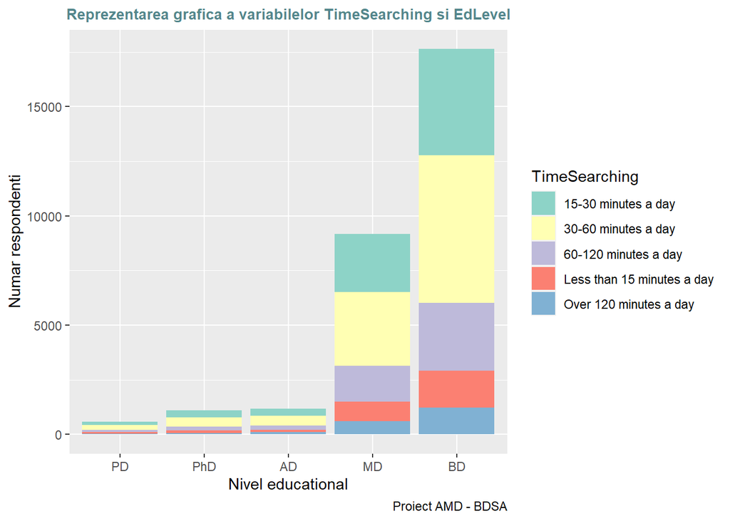

```r
date2022subset %>%
  filter(!is.na(TimeSearching)) %>%
  group_by(TimeSearching, EdLevel1) %>%
  dplyr::summarise(n = n()) %>%
  mutate(freq = n/sum(n)) %>%
  ggplot() +
  theme_set(theme_gray()) +
  geom_col(aes(x = reorder(EdLevel1, n), y = n, fill = TimeSearching)) +
  labs(x = "Nivel educational",
       y = "Numar respondenti",
       caption = "Proiect AMD - BDSA") +
  scale_fill_brewer(palette = "Set3") +
  ggtitle("Reprezentarea grafica a variabilelor TimeSearching si EdLevel") +
  theme(plot.title = element_text(hjust = 0.5, size = 10, color = "cadetblue4", face = "bold"))
```

Dupa schimbarea etichetelor si definirea noii variabile, urmeaza sa obtinem tabelul de contingenta al variabilelor TimeSearching si EdLevel1. Pentru aceasta, trebuie mai intai sa cream un model sub forma de tabel pe baza caruia sa putem aplica ulterior analiza corespondentelor.

```r
model_ac <- table(TimeSearching, EdLevel1)
```

```r
corespondente_TimeSearching <- ca(model_ac)
summary(corespondente_TimeSearching)
```

```
##
## Principal inertias (eigenvalues):
##
##  dim    value      %   cum%   scree plot
##  1      0.000611  60.1  60.1  ***************
##  2      0.000317  31.2  91.2  ********
##  3      8.4e-050   8.3  99.5  **
##  4      5e-06000   0.5 100.0
##         -------- -----
##  Total: 0.001017 100.0
##
##
## Rows:
##     name   mass  qlt  inr    k=1 cor ctr    k=2 cor ctr
## 1 | 1530 |  281  979  166 |  -13 273  75 |  -21 706 376 |
## 2 | 3060 |  378  895  145 |   -5  57  14 |   18 838 389 |
## 3 | 6012 |  176  981  335 |   41 876 488 |  -14 105 113 |
## 4 | Ls15 |   97  965  184 |  -43 964 295 |   -2   1   1 |
## 5 | O120 |   69  671  170 |   34 449 127 |   24 222 121 |
##
## Columns:
##     name   mass  qlt  inr    k=1 cor ctr    k=2 cor ctr
## 1 |   AD |   39  298  103 |   19 134  23 |   21 165  55 |
## 2 |   BD |  594  925  117 |    7 262  51 |   11 662 248 |
## 3 |   MD |  310  993  182 |   -2   4   1 |  -24 989 578 |
## 4 |  PhD |   37  999  566 | -124 981 925 |   17  18  33 |
## 5 |   PD |   20  860   31 |    0   0   0 |  -37 860  87 |
```

Harta simetrica ne ajuta sa vizualizam modul in care au fost reprezentate variabilele in modelul de analiza a corespondentelor.

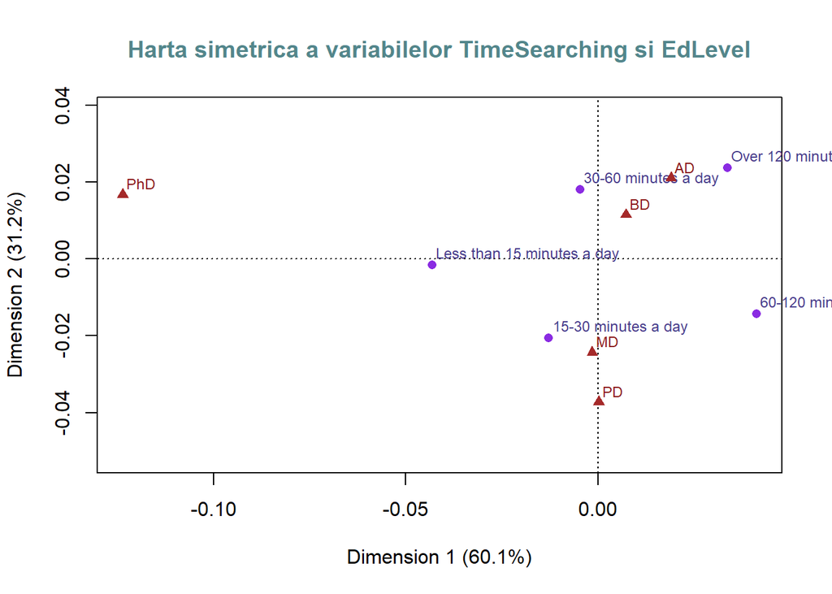

```r
plot(corespondente_TimeSearching, lines = c(FALSE, F), col = c("blueviolet", "brown"), col.lab = c("darkslateblue", "firebrick4"), main = "Harta simetrica a variabilelor TimeSearching si EdLevel", col.main = "cadetblue4")
```

In partea dreapta se afla respondentii care petrec cel mai mult timp cautand informatii necesare in rezolvarea problemelor intalnite la locul de munca, iar in partea stanga se regasesc cei care petrec cel mai putin timp.  
Observam faptul ca variabila AD se apropie cel mai mult de un timp de cautare de peste 120 minute, iar variabila BD pare ca se apropie cel mai mult de un timp petrecut cautarii de raspunsuri/solutii de 30-60 minute. Desi variabila AD se apropie cel mai mult de un timp de peste 120 minute, mentionam ca aceasta nu este bine reprezentata pe harta, fapt confirmat de valoarea mica a calitatii reprezentarii pe harta simetrica.  
In ceea ce priveste variabila PhD, remarcam o departare considerabila fata de profilul mediu al utilizatorilor, iar cel mai mult se apropie de acest profil respondetii care au BD.

Ca o masura de verificare a corectitudinii modelului ales, utilizam testul chi^2 si comparam valoarea p-value generata de acesta cu pragul de 0.05:

```r
chisq.test(model_ac)
```

```
##
##  Pearson's Chi-squared test
##
## data:  model_ac
## X-squared = 30.154, df = 16, p-value = 0.01722
```

Din valoarea p-value egala cu 0.01722, mai mica decat pragul de 0.05, putem afirma faptul ca modelul ales este corect, cele doua variabile fiind bine selectate pentru efectuarea acestui tip de analiza.  
**Partea a II-a**. Aplicarea unui model de regresie logistica pentru a explica factorii care determina alegerea unui job bine platit in domeniul IT.  
In cadrul acestei analize vom utiliza urmatoarele variabile pentru modelele de clasificatori:

- Wellpaid - variabila ce evidentiaza daca un job este bine platit sau nu
- Age - variabila care exprima grupurile de varsta in care se incadreaza fiecare respondent
- EdLevel - variabila care retine nivelul de educatie avut de catre respondenti
- YearsCodePro - variabila care afiseaza de cati ani codeaza developerii, strict in cadrul jobului
- WorkExp - variabila care evidentiaza numarul de ani de experienta
- RemoteWork - variabila care arata modul actual de lucru al respondentilor

In prima faza, pentru a putea defini corect modelul, variabilele alese trebuie mai intai sa fie prelucrate.  
1. Variabila Age:

```r
table(date2022$Age)
```

```
##
##    18-24 years old    25-34 years old    35-44 years old    45-54 years old
##              16646              28112              13988               5281
##    55-64 years old  65 years or older  Prefer not to say Under 18 years old
##               1978                554                521               3866
```

Vom alege doar primele 5 categorii de varsta, intrucat “Less than 18 years”, “More than 65 years” si “Prefer not to say” nu consider a fi relevante pentru aceasta analiza. Dupa selectarea acestora, ne vom crea un set de date filtrate pe care il vom utiliza in continuare.

```r
age <- c("18-24 years old", "25-34 years old", "35-44 years old", "45-54 years old", "55-64 years old")
# length(age)

date2022filtrate <- date2022 %>%
  filter(Age %in% age)
```

```r
# View(date2022filtrate)
dim(date2022filtrate)
```

```
## [1] 66005    79
```

```r
table(date2022filtrate$Age)
```

```
##
## 18-24 years old 25-34 years old 35-44 years old 45-54 years old 55-64 years old
##           16646           28112           13988            5281            1978
```

Pentru o mai usoara vizualizare a categoriilor de varsta alese, le vom schimba etichetele si retine intr-o noua variabila denumita Age1, ce va fi ulterior folosita in modelul de regresie logistica.

- 18-24 years old -> 18-24
- 25-34 years old -> 25-34
- 35-44 years old -> 35-44
- 45-54 years old -> 45-54
- 55-64 years old -> 55-64

```r
date2022filtrate$Age1 <- factor(date2022filtrate$Age,
                                labels = c("18-24", "25-34", "35-44", "45-54", "55-64"))
```

2. Variabila EdLevel:

```r
table(date2022filtrate$EdLevel)
```

```
##
##                                                Associate degree (A.A., A.S., etc.)
##                                                                               2181
##                                       Bachelor’s degree (B.A., B.S., B.Eng., etc.)
##                                                                              29697
##                                    Master’s degree (M.A., M.S., M.Eng., MBA, etc.)
##                                                                              15115
##                                         Other doctoral degree (Ph.D., Ed.D., etc.)
##                                                                               2040
##                                                          Primary/elementary school
##                                                                                564
##                                                 Professional degree (JD, MD, etc.)
##                                                                               1073
## Secondary school (e.g. American high school, German Realschule or Gymnasium, etc.)
##                                                                               5437
##                             Some college/university study without earning a degree
##                                                                               8933
##                                                                     Something else
##                                                                                881
```

Asemanator procesului aplicat anterior variabilei Age, vom schimba etichetele si le vom retine intr-o noua variabila denumita EdLevel1, astfel:

- Associate degree (A.A., A.S., etc.) - AD
- Bachelor’s degree (B.A., B.S., B.Eng., etc.) - BD
- Master’s degree (M.A., M.S., M.Eng., MBA, etc.) - MD
- Other doctoral degree (Ph.D., Ed.D., etc.) - PhD
- Primary/elementary school - P/ES
- Professional degree (JD, MD, etc.) - PD
- Secondary school (e.g. American high school, German Realschule or Gymnasium, etc.) - SS
- Some college/university study without earning a degree - C/UwD
- Something else - se

```r
date2022filtrate$EdLevel1 <- factor(date2022filtrate$EdLevel,
                                    labels = c("AD", "BD", "MD", "PhD", "P/ES", "PD", "SS", "C/UwD", "se"))
```

3. Variabila YearsCodePro:

```r
table(date2022filtrate$YearsCodePro)
```

```
##
##                  1                 10                 11                 12
##               2590               3291               1362               1688
##                 13                 14                 15                 16
##                902               1031               1797                910
##                 17                 18                 19                  2
##                713                773                375               3873
##                 20                 21                 22                 23
##               1424                421                912                453
##                 24                 25                 26                 27
##                444                853                310                274
##                 28                 29                  3                 30
##                246                120               4201                533
##                 31                 32                 33                 34
##                117                207                119                106
##                 35                 36                 37                 38
##                238                104                 90                 86
##                 39                  4                 40                 41
##                 46               3849                120                 28
##                 42                 43                 44                 45
##                 38                 16                 11                 14
##                 46                 47                 48                 49
##                  5                  2                  2                  1
##                  5                 50                  6                  7
##               4009                  1               3144               2742
##                  8                  9   Less than 1 year More than 50 years
##               2622               1564               1914                  3
```

Observam faptul ca avem doua variabile categoriale, si anume “Less than 1 year” si “More than 50 years”. Ne dorim ca variabila YearsCodePro sa fie de tip numeric, astfel ca vom modifica cele doua valori in felul urmator:

- Less than 1 year va fi inlocuita cu 0.5
- More than 50 years va fi inlocuita cu 51

De asemenea, variabila contine si valori NA pentru acei respondenti care nu au oferit niciun raspuns la intrebare, acestea urmand sa fie inlocuite cu 0. Noile valori vor fi retinute intr-o noua variabila denumita YearsCodePro1.

```r
date2022filtrate <- date2022filtrate %>%
  mutate(YearsCodePro1 = as.numeric(case_when(YearsCodePro == "Less than 1 year" ~ "0.5",
                                              YearsCodePro == "More than 50 years" ~ "51",
                                              is.na(YearsCodePro) == TRUE ~ "0",
                                              TRUE ~ YearsCodePro)))
```

Reprezentam grafic frecventa de aparitie prin intermediul unei histograme. Aceasta ne va ajuta sa grupam pe categorii anii de codat notati de catre respondenti.

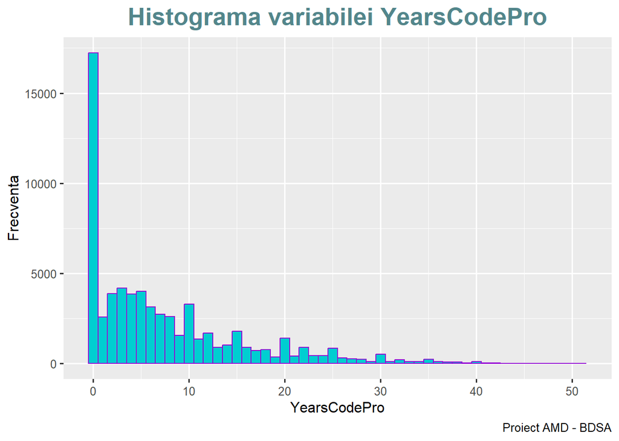

```r
date2022filtrate %>%
  filter(!is.na(YearsCodePro1)) %>%
  ggplot() +
  geom_histogram(aes(x = YearsCodePro1), color = "darkviolet", fill = "darkturquoise", na.rm = TRUE, binwidth = 1) +
  labs(x = "YearsCodePro",
       y = "Frecventa",
       caption = "Proiect AMD - BDSA") +
  ggtitle("Histograma variabilei YearsCodePro") +
  theme_gray(base_size = 12) +
  theme(plot.title = element_text(hjust = 0.5, size = 20, color = "cadetblue4", face = "bold"))
```

In histograma anterioara se observa faptul ca cele mai multe raspunsuri au fost inregistrate pentru valoarea 0, fapt datorat in mare parte si inlocuirii valorilor NA tot cu 0. Dupa analizarea histogramei, se vor forma urmatoarele categorii de ani: 0-10 ani, 11-20 ani, 21-30 ani si peste 30 ani; acestea vor fi retinute intr-o noua variabila denumita YearsCodePro2.

```r
date2022filtrate <- date2022filtrate %>%
  mutate(YearsCodePro2 = as.factor(case_when(YearsCodePro1 <= 10 ~ "0-10",
                                             YearsCodePro1 <= 20 ~ "11-20",
                                             YearsCodePro1 <= 30 ~ "21-30",
                                             YearsCodePro1 > 30 ~ "30+")))
```

4. Variabila WorkExp:

Pentru a determina nivelul maxim de experienta al respondentilor, utilizam statisticile descriptive si observam ca acesta atinge valoarea de 50 ani.

```r
summary(date2022filtrate$WorkExp)
```

```
##    Min. 1st Qu.  Median    Mean 3rd Qu.    Max.    NA's
##    0.00    4.00    8.00   10.13   15.00   50.00   29689
```

Aplicam functia de densitate variabilei WorkExp si o reprezentam grafic pentru a putea repartiza anii de experienta ai developerilor pe categorii.

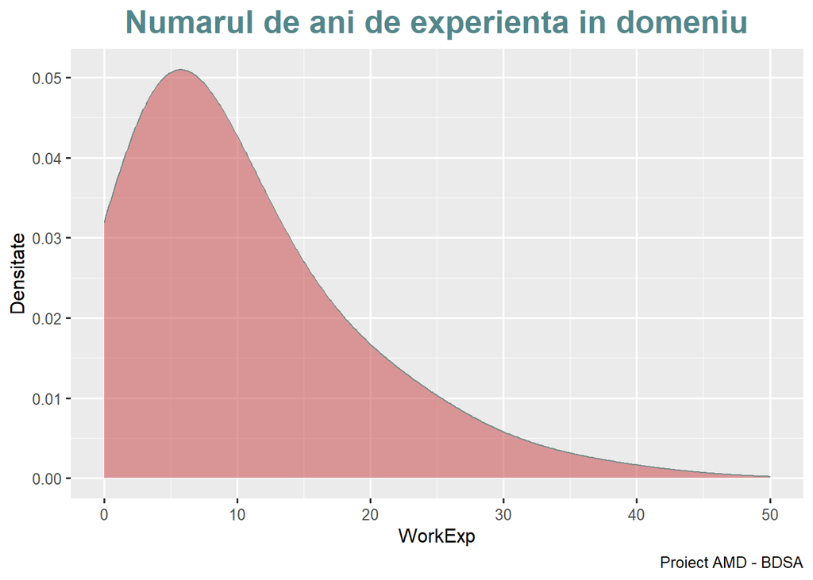

```r
date2022filtrate %>%
  filter(!is.na(WorkExp)) %>%
  ggplot(aes(WorkExp)) +
  geom_density(color = "lightcyan4", fill = "indianred", adjust = 5, alpha = .6) +
  labs(x = "WorkExp",
       y = "Densitate",
       caption = "Proiect AMD - BDSA") +
  ggtitle("Numarul de ani de experienta in domeniu") +
  theme_gray(base_size = 12) +
  theme(plot.title = element_text(hjust = 0.5, size = 20, color = "cadetblue4", face = "bold"))
```

Din graficul anterior stabilim urmatoarele categorii pentru numarul de ani de experinta; acestea vor fi memorate intr-o noua variabila denumita WorkExp1:

```r
date2022filtrate <- date2022filtrate %>%
  mutate(WorkExp1 = as.factor(case_when(WorkExp < 5 ~ "0-4",
                                        WorkExp <= 10 ~ "5-10",
                                        WorkExp <= 20 ~ "11-20",
                                        WorkExp > 20 ~ "20+")))
```

5. Variabila RemoteWork:

```r
table(date2022filtrate$RemoteWork)
```

```
##
##                       Full in-person                         Fully remote
##                                 8312                                24569
## Hybrid (some remote, some in-person)
##                                24469
```

Fiind o variabila categoriala, vom proceda asemanator ca pentru variabilele Age si EdLevel, schimband etichetele in felul urmator:

- Full in-person - FIP
- Fully remote - FR
- Hybrid (some remote, some in-person) - H

```r
date2022filtrate$RemoteWork1 <- factor(date2022filtrate$RemoteWork,
                                       labels = c("FIP", "FR", "H"))
```

Asa cum am mentionat anterior, in modelul de regresie logistica vor fi utilizate variabilele prelucrate, si anume: Age1, EdLevel1, YearsCodePro2, WorkExp1 si RemoteWork1. Generam statisticile descriptive ale noilor variabile pentru a vedea informatii referitoare la valorile minime/maxime, media etc. si, de asemenea, daca exista valori NA.

```r
summary(date2022filtrate %>%
          select(c(Age1, EdLevel1, YearsCodePro2, WorkExp1, RemoteWork1)))
```

```
##     Age1          EdLevel1     YearsCodePro2  WorkExp1     RemoteWork1
##  18-24:16646   BD     :29697   0-10 :49110   0-4  :10885   FIP : 8312
##  25-34:28112   MD     :15115   11-20:10975   11-20: 8519   FR  :24569
##  35-44:13988   C/UwD  : 8933   21-30: 4566   20+  : 4401   H   :24469
##  45-54: 5281   SS     : 5437   30+  : 1354   5-10 :12511   NA's: 8655
##  55-64: 1978   AD     : 2181                 NA's :29689
##                (Other): 4558
##                NA's   :   84
```

Din statisticle descriptive de mai sus reiese faptul ca 3 dintre cele 5 variabile ce se doresc a fi utilizate in model contin valori NA. Acestea vor fi ulterior eliminate din model, intrucat nu pot fi utilizate in regresia logistica intrucat nu au sens.  
Urmatorul pas consta in definirea variabilei Wellpaid pe baza variabilei ConvertedCompYearly care retine salariul anual declarat de catre respondenti.

```r
summary(date2022filtrate$ConvertedCompYearly)
```

```
##     Min.  1st Qu.   Median     Mean  3rd Qu.     Max.     NA's
##        1    35832    67550   170322   120000 50000000    28291
```

[figure not shown]

```r
date2022filtrate %>%
  filter(!is.na(ConvertedCompYearly)) %>%
  ggplot() +
  geom_histogram(aes(x = WorkExp),color = "mediumvioletred", fill = "mistyrose2", na.rm = TRUE, binwidth = 1) +
  labs(x = "ConvertedCompYearly",
       y = "Frecventa",
       caption = "Proiect AMD - BDSA") +
  ggtitle("Salariul anual incasat de developeri") +
  theme(plot.title = element_text(hjust = 0.5, size = 20, color = "cadetblue4", face = "bold"))
```

```r
dim(date2022filtrate)
```

```
## [1] 66005    85
```

Prelucram variabila ConvertedCompYearly prin eliminarea din continutul acesteia a valorilo NA pentru a nu intampina probleme in modelarea regresiei logistice:

```r
date2022model <- date2022filtrate %>%
  filter(!is.na(ConvertedCompYearly))
```

```r
# View(date2022model)
dim(date2022model)
```

```
## [1] 37714    85
```

In urma efectuarii acestei prelucrari, putem incepe construirea variabilei Wellpaid, astfel:

- Daca salariul anual este mai mic decat valoarea medianei sale, atunci va fi incadrat in categoria Not Wellpaid notata cu 0
- Daca salariul anual este mai mare sau egal cu valoarea medianei sale, atunci va fi incadrat in categoria Wellpaid notata cu 1

```r
date2022model <- date2022model %>%
  mutate(Wellpaid = as.factor(case_when(ConvertedCompYearly < median(ConvertedCompYearly) ~ 0,
                                        ConvertedCompYearly >= median(ConvertedCompYearly) ~ 1)))
```

Analizam statisticile descriptive ale variabilelor prelucrate anterior si observam faptul ca avem 18853 de respondenti care se afla in categoria Not Wellpaid (0) si 18861 de respondenti care se afla in categoria Wellpaid (1).

```r
summary(date2022model %>%
          select(c(Wellpaid, Age1, EdLevel1, YearsCodePro2, WorkExp1, RemoteWork1)))
```

```
##  Wellpaid     Age1          EdLevel1     YearsCodePro2  WorkExp1
##  0:18853   18-24: 4908   BD     :17941   0-10 :25482   0-4  : 7407
##  1:18861   25-34:18707   MD     : 9775   11-20: 8174   11-20: 6630
##            35-44: 9682   C/UwD  : 4447   21-30: 3159   20+  : 3286
##            45-54: 3286   SS     : 1742   30+  :  899   5-10 : 9609
##            55-64: 1131   PhD    : 1343                 NA's :10782
##                          (Other): 2451
##                          NA's   :   15
##  RemoteWork1
##  FIP : 4528
##  FR  :17254
##  H   :15889
##  NA's:   43
##
##
##
```

```r
date2022na <- date2022model %>%
  filter(!is.na(Age1), !is.na(EdLevel1), !is.na(YearsCodePro2), !is.na(WorkExp1), !is.na(RemoteWork1))
```

Dat fiind faptul ca toate variabilele au fost prelucrate, putem construi modelul de regresie logistica.

```r
model_rl <- glm(Wellpaid ~ Age1 + EdLevel1 + YearsCodePro2 + WorkExp1 + RemoteWork1,
                family = "binomial",
                data = date2022na)

summary(model_rl)
```

```
##
## Call:
## glm(formula = Wellpaid ~ Age1 + EdLevel1 + YearsCodePro2 + WorkExp1 +
##     RemoteWork1, family = "binomial", data = date2022na)
##
## Deviance Residuals:
##     Min       1Q   Median       3Q      Max
## -2.2691  -1.0475  -0.4814   1.0427   2.5883
##
## Coefficients:
##                    Estimate Std. Error z value Pr(>|z|)
## (Intercept)        -2.27659    0.09336 -24.384  < 2e-16 ***
## Age125-34           0.45761    0.05091   8.988  < 2e-16 ***
## Age135-44           0.68310    0.06297  10.848  < 2e-16 ***
## Age145-54           0.71874    0.09327   7.706 1.30e-14 ***
## Age155-64           1.11431    0.15453   7.211 5.55e-13 ***
## EdLevel1BD          0.17966    0.07711   2.330 0.019803 *
## EdLevel1MD          0.04491    0.07922   0.567 0.570768
## EdLevel1PhD         0.49468    0.10803   4.579 4.67e-06 ***
## EdLevel1P/ES        0.13700    0.20396   0.672 0.501772
## EdLevel1PD         -1.03734    0.13805  -7.514 5.72e-14 ***
## EdLevel1SS         -0.35841    0.09962  -3.598 0.000321 ***
## EdLevel1C/UwD      -0.21128    0.08415  -2.511 0.012046 *
## EdLevel1se         -0.25794    0.16347  -1.578 0.114591
## YearsCodePro211-20  0.30273    0.05448   5.557 2.75e-08 ***
## YearsCodePro221-30  0.50205    0.09889   5.077 3.84e-07 ***
## YearsCodePro230+    0.62670    0.16676   3.758 0.000171 ***
## WorkExp111-20       1.07734    0.05999  17.958  < 2e-16 ***
## WorkExp120+         1.41324    0.09891  14.288  < 2e-16 ***
## WorkExp15-10        0.74102    0.03766  19.677  < 2e-16 ***
## RemoteWork1FR       1.12280    0.04728  23.750  < 2e-16 ***
## RemoteWork1H        0.77995    0.04755  16.401  < 2e-16 ***
## ---
## Signif. codes:  0 '***' 0.001 '**' 0.01 '*' 0.05 '.' 0.1 ' ' 1
##
## (Dispersion parameter for binomial family taken to be 1)
##
##     Null deviance: 37279  on 26902  degrees of freedom
## Residual deviance: 32581  on 26882  degrees of freedom
## AIC: 32623
##
## Number of Fisher Scoring iterations: 4
```

Statisticile descriptive ale modelului de regresie logistica prezinta informatii importante referitoare la devianta modelului. Astfel, daca devianta reziduala este mai mica decat devianta nula, putem afirma faptul ca raspunsul prognozat un model in care se adauga variabilele independente este mai bun decat raspunsul dat de un model in care apare doar variabila dependenta. In cazul regresiei noastre, remarcam ca valoarea specifica Residual deviance, egala cu 32581, este mai mica decat valoarea Null deviance, egala cu 37279.

In urma generarii modelului de regresie logistica si a statisticilor descriptive corespunzatoare acestuia, urmatoarea etapa consta in interpretarea coeficientilor modelului. Asa cum am observat in output-ul de mai sus, apelarea statisticilor descriptive ale modelului ofera informatii referitoare la valorile coeficientilor, insa acestea sunt sub forma de logaritm natural. Astfel, este necesara aplicarea functia exp() pentru a genera valorile interpretabile ale regresiei logistice.

```r
exp(coef(model_rl))
```

```
##        (Intercept)          Age125-34          Age135-44          Age145-54
##          0.1026339          1.5802954          1.9800064          2.0518452
##          Age155-64         EdLevel1BD         EdLevel1MD        EdLevel1PhD
##          3.0474792          1.1968140          1.0459380          1.6399677
##       EdLevel1P/ES         EdLevel1PD         EdLevel1SS      EdLevel1C/UwD
##          1.1468319          0.3543949          0.6987896          0.8095440
##         EdLevel1se YearsCodePro211-20 YearsCodePro221-30   YearsCodePro230+
##          0.7726450          1.3535541          1.6521099          1.8714284
##      WorkExp111-20        WorkExp120+       WorkExp15-10      RemoteWork1FR
##          2.9368699          4.1092399          2.0980841          3.0734343
##       RemoteWork1H
##          2.1813573
```

In ceea ce priveste variabila Age1, categoria de baza pentru referirea celorlalte variabile contine varstele 18-24 ani. Astfel spus, observam faptul ca developerii aflati in segmentul 25-34 ani au sanse cu aproximativ 58% mai mari de a se incadra in categoria Wellpaid fata de categoria de baza. In ceea ce priveste developerii cu varstele cuprinse intre 35-44 ani si 45-54 ani, sansele de a se regasi in categoria Wellpaid cresc cu o probablitate de aproximativ 98%, respectiv 105.2% fata de segmentul de baza. Remarcam faptul ca, odata cu inaintarea in varsta si incadrarea intr-o categorie diferita cresc sansele de a fi bine platit, pentru respondentii avand varsta intre 55-64 observandu-se o crestere a sanselor de incadrare in aceasta categorie cu o probabilitate de 204.7% , acestia fiind cei care au cea mai mare experienta in domeniu.

In cazul variabilei YearsCodePro2, categoria de baza este de 0-10 ani, odata cu intrarea in cea de-a doua categorie, si anume 11-20 ani, sansele ca un developer sa fie bine platit cresc cu o probabilitate de 35.4%. Odata cu incadrarea intr-o noua categorie de ani, cresc si sansele de incadrare in segmentul Wellpaid, pentru cei cu o experienta de codat la locul de munca de 21-30 ani cu o probabilitate de 65.2%, respectiv pentru cei care au peste 30 ani de experienta, cu o probabilitate de aproximativ 87%. Se considera ca, odata cu inaintarea in varsta, creste si incadrarea in categoria de ani de experienta, insa exista multi developeri care pe parcursul carierei pot sa schimbe limbajul de programare folosit la locul de munca si, in acest fel, ei se pot avea varsta cuprinsa intre 35-44 ani insa sa fi utilizat respectivul limbaj de programare pe o perioada de 5 ani.

In urma interpretarii coeficientilor modelului de regresie logistica, vom analiza cat de bun este acesta prin construirea curbei ROC si a determinarii valorii ariei de sub curba ROC (AUC - Area Under the Curve). Ulterior, vom construi matricea de confuzie corespunzatoare modelului.  
In construirea curbei ROC, primul pas consta in determinarea probabilitatilor estimate ale regresiei logistice si codificarea predicitiilor din clasele Wellpaid si Not Wellpaid cu 1, respectiv 0.

```r
pred <- predict(model_rl, type = "response")
length(pred)
```

```
## [1] 26903
```

```r
summary(pred)
```

```
##    Min. 1st Qu.  Median    Mean 3rd Qu.    Max.
##  0.0351  0.2975  0.4916  0.4875  0.6483  0.9238
```

Din statisticile descriptive generate anterior pentru probabilitatile estimate ale modelului, observam ca avem un prag egal cu 0.49, valoare ce corespunde medianei. Astfel, vom imparti predictiile asemanator cu procesul utilizat in crearea variabilei Wellpaid pe baza salariului anual:

- Daca valoarea probabilitatii estimate este mai mare decat pragul ales, atunci va fi incadrata in clasa 1
- Daca valoarea probabilitatii estimate este mai mica decat pragul ales, atunci va fi incadrata in clasa 0

```r
y_pred_num <- ifelse(pred > 0.49, 1, 0)
table(y_pred_num)
```

```
## y_pred_num
##     0     1
## 13430 13473
```

Dupa efectuarea repartitiei valorilor in functie de pragul de 0.49, observam ca avem 13430 de respondenti ce se afla in categoria Not Wellpaid si 13473 dintre acestia au fost incadrati in categoria Wellpaid, esantionul fiind impartit aproape in mod egal.

```r
y_pred <- factor(y_pred_num, labels = c(0, 1))
predictie <- prediction(pred, date2022na$Wellpaid)
```

In urma atribuirii respondentilor in clasele corespunzatoare, urmeaza sa construim curba ROC si sa determinam valoarea ariei de sub curba ROC.

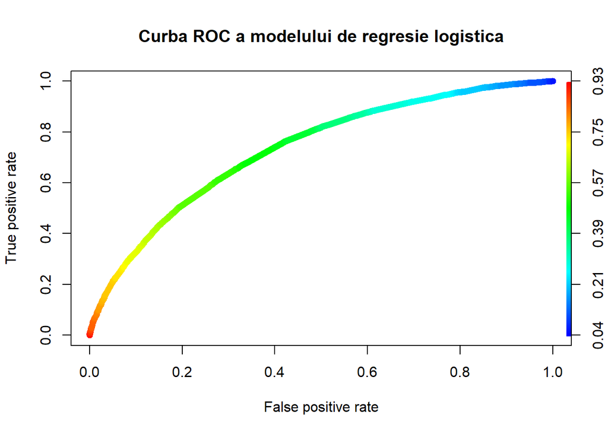

```r
predictie %>%
  performance(measure = "tpr", x.measure = "fpr") %>%
  plot(colorize = T, lwd = 7, main = "Curba ROC a modelului de regresie logistica")
```

Valoarea ariei de sub graficul curbei ROC este egala cu 0.73, asa cum observam in output-ul de mai jos. AUC masoara performanta tuturor pragurilor de clasificare posibile si trebuie sa aiba o valoare cat mai mare pentru ca modelul ales sa fie considerat bun. Astfel, modelul de regresie logistica are o probabilitate de aproximativ 73%, corespunzatoare unei clasificari moderate de a plasa variabilele in zona de true positiv rate, fata de o plasate a lor in zona de false positive rate.

```r
auc_rl <- performance(predictie, "auc")@y.values[[1]]
auc_rl
```

```
## [1] 0.7325576
```

```r
confusionMatrix(data = y_pred, as.factor(date2022na$Wellpaid))
```

```
## Confusion Matrix and Statistics
##
##           Reference
## Prediction    0    1
##          0 9168 4262
##          1 4621 8852
##
##                Accuracy : 0.6698
##                  95% CI : (0.6642, 0.6754)
##     No Information Rate : 0.5125
##     P-Value [Acc > NIR] : < 2.2e-16
##
##                   Kappa : 0.3397
##
##  Mcnemar's Test P-Value : 0.0001456
##
##             Sensitivity : 0.6649
##             Specificity : 0.6750
##          Pos Pred Value : 0.6827
##          Neg Pred Value : 0.6570
##              Prevalence : 0.5125
##          Detection Rate : 0.3408
##    Detection Prevalence : 0.4992
##       Balanced Accuracy : 0.6699
##
##        'Positive' Class : 0
##
```

**Partea a III-a**. Aplicarea unui arbore de clasificare folosind pachetul rpart. Vom utiliza aceleasi variabile ca si in cazul modelului de regresie definit anterior.

In ceea ce priveste lucrul cu arborii de clasificare, este necesara extragerea unui set de date de antrenare continand 80% din setul de date complet. Dimensiunea setului de date prelucrat este egala cu 26903, 80% din acesta fiind egal cu 21522.4. Rotunjim si retinem in variabila de antrenare doar raspunsurile oferite de 21522 developeri.

```r
set_antrenare <- sample(1:26903, 21522, replace = F)
```

Cream arborele pe baza acelorasi variabilele utilizate in modelul de regresie, si anume: Wellpaid, Age1, EdLevel1, YearsCodPro2, WorkExp si RemoteWork1, precum si a setului de date ce nu contine valori NA din cadrul celor trei variabile mentionate anterior. De asemenea, din acest set de date, vor fi selectati doar cei 80% dintre respondenti, adica setul de antrenare generat anterior.

```r
arbore <- rpart(Wellpaid ~ Age1 + EdLevel1 + YearsCodePro2 + WorkExp1 + RemoteWork1,
                data = date2022na[set_antrenare, ],
                method = "class",
                parms = list(split = "information"),
                control = rpart.control(cp = 0.004))
summary(arbore)
```

```
## Call:
## rpart(formula = Wellpaid ~ Age1 + EdLevel1 + YearsCodePro2 +
##     WorkExp1 + RemoteWork1, data = date2022na[set_antrenare,
##     ], method = "class", parms = list(split = "information"),
##     control = rpart.control(cp = 0.004))
##   n= 21522
##
##            CP nsplit rel error    xerror        xstd
## 1 0.283250762      0 1.0000000 1.0000000 0.006986437
## 2 0.006256352      1 0.7167492 0.7167492 0.006664674
## 3 0.005907012      4 0.6979802 0.7120808 0.006654550
## 4 0.004000000      6 0.6861662 0.6993140 0.006626003
##
## Variable importance
##      WorkExp1 YearsCodePro2          Age1   RemoteWork1      EdLevel1
##            44            26            26             3             1
##
## Node number 1: 21522 observations,    complexity param=0.2832508
##   predicted class=0  expected loss=0.487687  P(node) =1
##     class counts: 11026 10496
##    probabilities: 0.512 0.488
##   left son=2 (13593 obs) right son=3 (7929 obs)
##   Primary splits:
##       WorkExp1      splits as  LRRL,      improve=1021.20200, (0 missing)
##       YearsCodePro2 splits as  LRRR,      improve= 923.13400, (0 missing)
##       Age1          splits as  LLRRR,     improve= 831.61320, (0 missing)
##       RemoteWork1   splits as  LRR,       improve= 315.97800, (0 missing)
##       EdLevel1      splits as  RRRRRLLRL, improve=  55.98284, (0 missing)
##   Surrogate splits:
##       YearsCodePro2 splits as  LRRR,  agree=0.926, adj=0.798, (0 split)
##       Age1          splits as  LLRRR, agree=0.865, adj=0.634, (0 split)
##
## Node number 2: 13593 observations,    complexity param=0.006256352
##   predicted class=0  expected loss=0.3711469  P(node) =0.6315863
##     class counts:  8548  5045
##    probabilities: 0.629 0.371
##   left son=4 (5914 obs) right son=5 (7679 obs)
##   Primary splits:
##       WorkExp1      splits as  L--R,      improve=345.69170, (0 missing)
##       Age1          splits as  LRRRR,     improve=228.15210, (0 missing)
```

[output cut: 79 more lines]

```
##       Age1          splits as  LR---,     improve=4.175943, (0 missing)
##       EdLevel1      splits as  -L-RL----, improve=2.627884, (0 missing)
##   Surrogate splits:
##       EdLevel1 splits as  -R-LR----, agree=0.531, adj=0.027, (0 split)
##       Age1     splits as  LR---,     agree=0.522, adj=0.008, (0 split)
##
## Node number 90: 1510 observations
##   predicted class=0  expected loss=0.4794702  P(node) =0.07016077
##     class counts:   786   724
##    probabilities: 0.521 0.479
##
## Node number 91: 1624 observations
##   predicted class=1  expected loss=0.4618227  P(node) =0.07545767
##     class counts:   750   874
##    probabilities: 0.462 0.538
```

```r
printcp(arbore)
```

```
##
## Classification tree:
## rpart(formula = Wellpaid ~ Age1 + EdLevel1 + YearsCodePro2 +
##     WorkExp1 + RemoteWork1, data = date2022na[set_antrenare,
##     ], method = "class", parms = list(split = "information"),
##     control = rpart.control(cp = 0.004))
##
## Variables actually used in tree construction:
## [1] Age1        EdLevel1    RemoteWork1 WorkExp1
##
## Root node error: 10496/21522 = 0.48769
##
## n= 21522
##
##          CP nsplit rel error  xerror      xstd
## 1 0.2832508      0   1.00000 1.00000 0.0069864
## 2 0.0062564      1   0.71675 0.71675 0.0066647
## 3 0.0059070      4   0.69798 0.71208 0.0066545
## 4 0.0040000      6   0.68617 0.69931 0.0066260
```

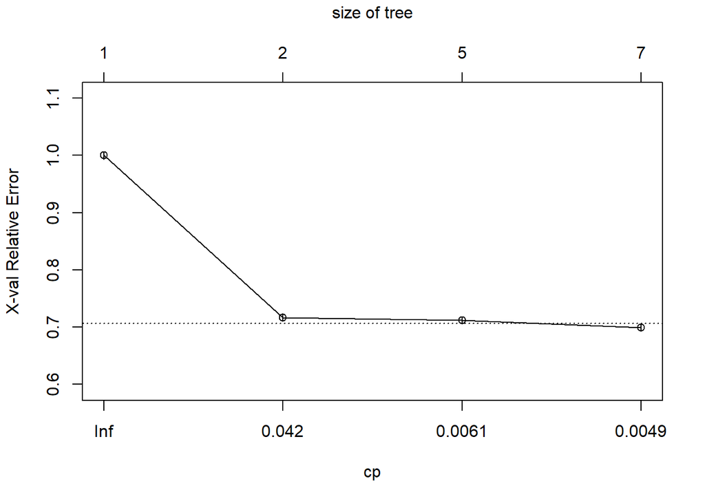

```r
plotcp(arbore)
```

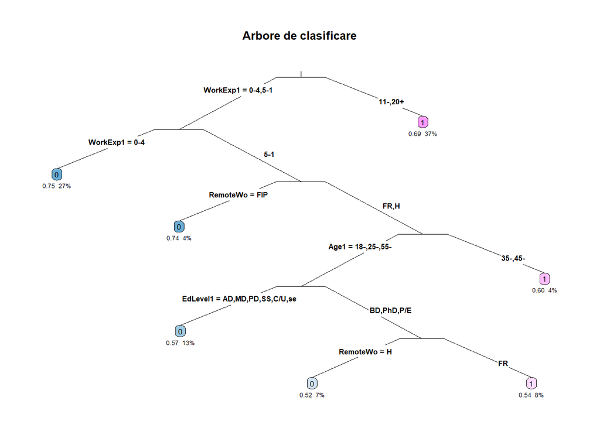

```r
prp(arbore, type = 3, extra = 108, box.palette = "BuPu", under = TRUE, fallen.leaves = F,
    main = "Arbore de clasificare")
```

Asemanator cu ceea ce s-a realizat anterior pentru modelul de regresie, vom genera curba ROC a arborelui de clasificare si vom determina valoarea ariei de sub aceasta folosindu-ne de setul de testare continand din cei 20% de respondenti ramasi din intreg setul de date.

```r
pred1 <- predict(arbore, newdata = date2022na[-set_antrenare, ], type = "prob")[, 2]
predictie1 <- prediction(pred1, date2022na[-set_antrenare, ]$Wellpaid)
```

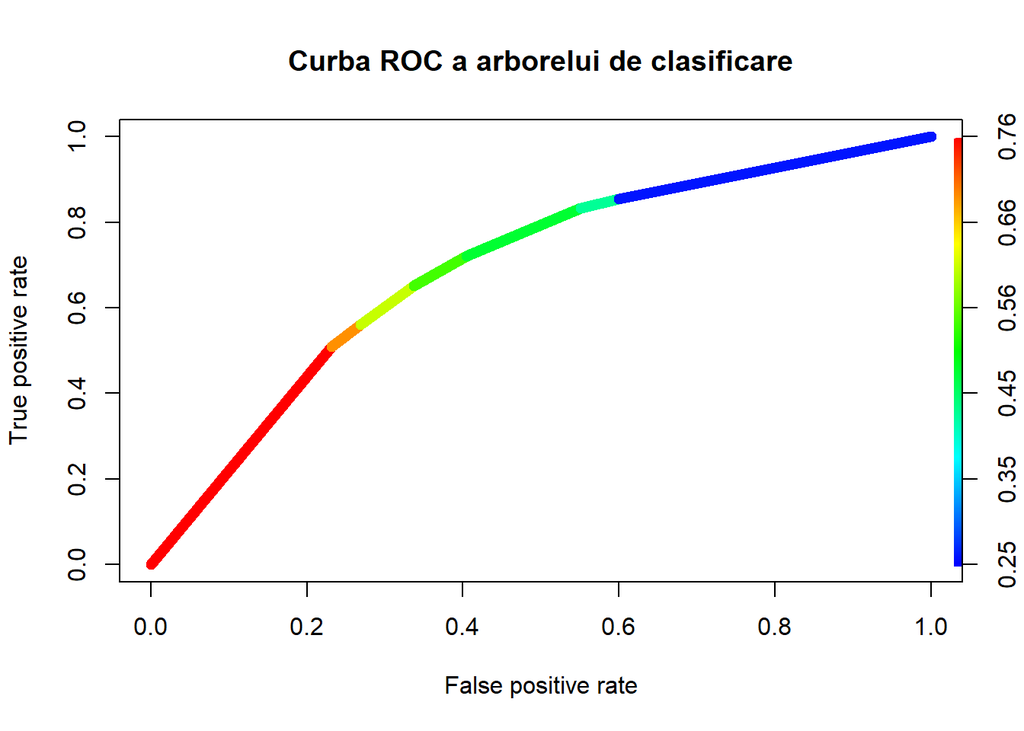

```r
predictie1 %>%
  performance(measure = "tpr", x.measure = "fpr") %>%
  plot(colorize = T, lwd = 7, main = "Curba ROC a arborelui de clasificare")
```

```r
auc_ar <- performance(predictie1, "auc")@y.values[[1]]
auc_ar
```

```
## [1] 0.6929965
```

Dupa efectuarea predictiilor pe setul de testare pentru clasele 0 - Not Wellpaid si 1 - Wellpaid, remarcam faptul ca 3169 dintre respondenti au fost incadrati ca nefiind bine platiti, iar 2212 dintre acestia ca fiind bine platiti.

```r
table(pred_ar)
```

[output not shown]

```
## pred_ar
##    0    1
## 3169 2212
```

```r
confusionMatrix(pred_ar, date2022na[-set_antrenare, ]$Wellpaid, mode = "everything", positive = "1")
```

```
## Confusion Matrix and Statistics
##
##           Reference
## Prediction    0    1
##          0 2020 1149
##          1  743 1469
##
##                Accuracy : 0.6484
##                  95% CI : (0.6355, 0.6612)
##     No Information Rate : 0.5135
##     P-Value [Acc > NIR] : < 2.2e-16
##
##                   Kappa : 0.2934
##
##  Mcnemar's Test P-Value : < 2.2e-16
##
##             Sensitivity : 0.5611
##             Specificity : 0.7311
##          Pos Pred Value : 0.6641
##          Neg Pred Value : 0.6374
##               Precision : 0.6641
##                  Recall : 0.5611
##                      F1 : 0.6083
##              Prevalence : 0.4865
##          Detection Rate : 0.2730
##    Detection Prevalence : 0.4111
##       Balanced Accuracy : 0.6461
##
##        'Positive' Class : 1
##
```

**Partea a IV-a**. Compararea rezultatelor modelului de regresie logistica si a arborelui de clasificare.

- Modelul de regresie logistica:

Aria de sub curba ROC este de aproximativ 73%, sugerand faptul ca a fost obtinut un clasificator de tip true positive rate mai bun decat cel de tip false positive rate. Am observat faptul ca acuratetea clasificarii modelului este de aproximativ 67%.

- Arborele de clasificare:

Aria de sub curba ROC este de aproximativ 69%, sugerand faptul ca a fost obtinut un clasificator de tip true positive rate mai bun decat cel de tip false positive rate. Am observat o acuratete a clasificarii arborelui egala cu aproximativ 65%.  
Pe baza valorilor foarte apropiate obtinute pentru AUC si acuratete atat in cazul regresiei logistice, cat si a arborelui de clasificare, putem afirma faptul ca modelul de regresie este mai bun decat arborele, chiar daca acuratetea si AUC nu sunt cu mult mai mari.

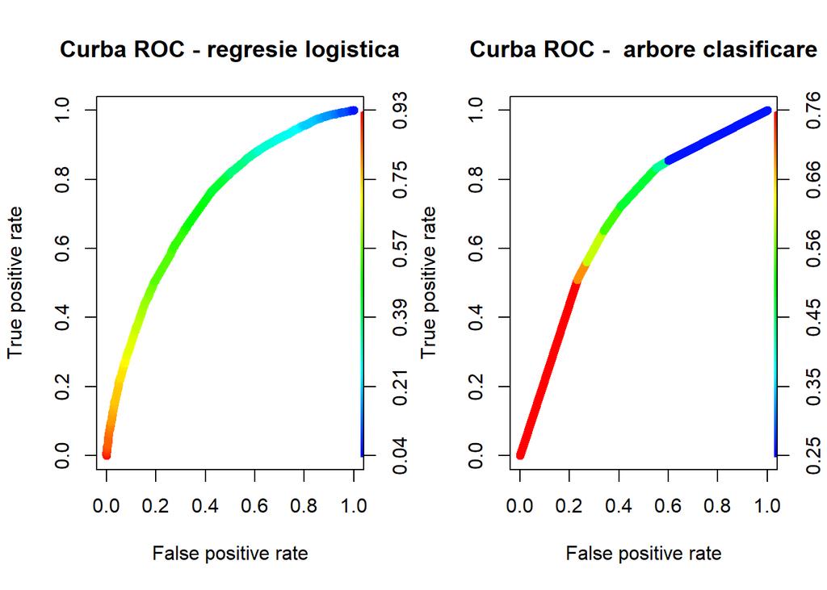

```r
par(mfrow = c(1, 2))

predictie %>%
  performance(measure = "tpr", x.measure = "fpr") %>%
  plot(colorize = T, lwd = 7, main = "Curba ROC - regresie logistica")

predictie1 %>%
  performance(measure = "tpr", x.measure = "fpr") %>%
  plot(colorize = T, lwd = 7, main = "Curba ROC -  arbore clasificare")
```